# Modelling Bird Characteristics

by Pipeline: Naomi Pihlaja, Jiaxi Yan, Yupeng Qiu, Jiayi Chen

2025-12-01

## Research Question

**Can we accurately predict certain characteristics of birds using chosen explanatory variables?**

(If we can, we could potentially predict the lifestyle elements of lesser known/ lesser investigated bird species: these predictions could be used in scientific research for wildlife conservation and investigation.)

## Data

figshare.com. (n.d.). AVONET: morphological, ecological and geographical data for all birds (Tobias et al 2022 Ecology Letters doi: https://doi.org/10.111/ele.13898). [online] Available at: https://figshare.com/s/b990722d72a26b5bfead.

# Introduction

A bird’s ecological traits, especially morphological, offer valuable insights into how they adapt to their environments, and thus also offer insights into the conditions of their environment. The AVONET Birdtree dataset includes data about thousands of bird species. Most of the data concerns measurements on their morphology (eg. Beak width), but it also contains data on their habitats and trophic ecology. This dataset allows us to investigate hypothesis regarding potential correlations of different bird traits, and of potential predictive modelling.

Our investigation concerned two key questions:

**1. To what extent can morphological traits explain ecological characteristic such as trophic level or latitude?** **2. Which morphological variables show meaningful correlations with each other?**

These questions were motivated by our hypothesis generated during group discussions, using logical thinking based on our knowledge of biology and animal adaptations based on lifestyle.

# Data Overview

Avonet birdtree contains summary statistics on specific characteristics of birds. Many are numerical variables (eg. Beak depth), but some are categorical (eg. Trophic level).Over 10,000 observations allows for a big sample size.

Our variables of interest (data we thought would be worth investigating after looking through the dataset) were as follows:

- **Habitat**: Where the bird lives
- **Trophic.level**: Categorical variable based on the composition of a birds’ diet
- **Hangwingindex**: A measurement of a bird’s wing shape that indicates flight efficiency and dispersal ability
- **Beak.width**: Width of the beak at the anterior edge of the nostrils
- **Beak.depth**: Depth of the beak at the anterior edge of the nostrils
- **Centroid.Latitude**: The geometric centre of the species range
- **Mass** : Body mass of species average
- **Wing.length** : Length from the carpal joint to the tip of the longest primary on the unflattened wing

# Exploratory Statistics

### 1. Correlation: Beak Width & Beak Depth

We began by exploring any correlations between traits we suspected to be related, based on our knowlegde of basic bird biology. After constructing a scatterplot with a linear model, the line of best fit indicated a strong positive correlation between beak width and beak depth.

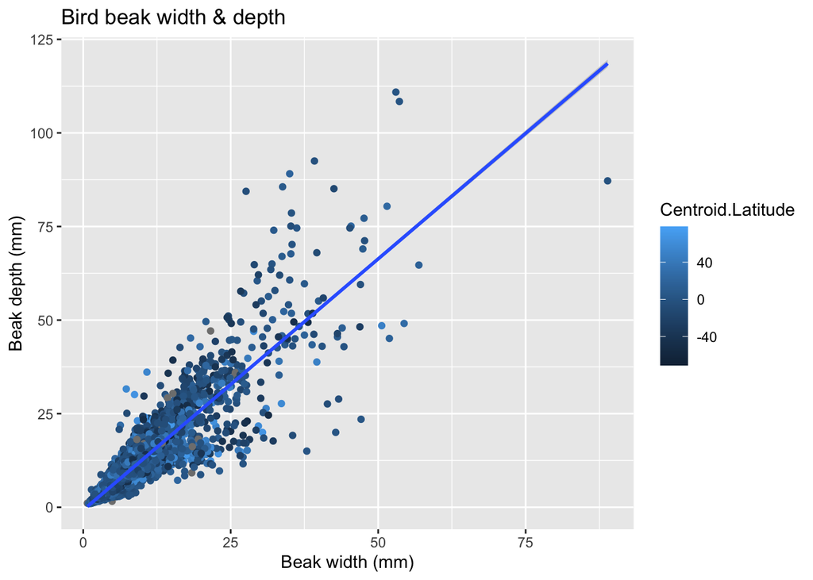

### 2.Predicting Latitude

We then attempted to predict centroid latitude using these morphological variables (beak width and length). However, our model showed no meaningful visual correlation- the colours were mixed throughout the plane of the graph. This suggested that the latitude of a bird’s habitat do not strongly affect their beak shape. The lack of correlation was confirmed by our model whcih attempted to use beak shape to predict latitude:

```
## # A tibble: 1,999 × 37
##    .pred Species3          Family3 Order3 Total.individuals Female  Male Unknown
##    <dbl> <chr>             <chr>   <chr>              <dbl>  <dbl> <dbl>   <dbl>
##  1  2.83 Accipiter brevip… Accipi… Accip…                 8      4     4       0
##  2  2.76 Accipiter castan… Accipi… Accip…                 6      2     2       2
##  3  2.78 Accipiter erythr… Accipi… Accip…                 4      3     1       0
##  4  1.42 Accipiter gundla… Accipi… Accip…                 1      0     1       0
##  5  2.61 Accipiter henico… Accipi… Accip…                 5      2     3       0
##  6  2.37 Accipiter luteos… Accipi… Accip…                 1      0     1       0
##  7  2.87 Accipiter tachiro Accipi… Accip…                 9      4     5       0
##  8  2.78 Accipiter trinot… Accipi… Accip…                 8      2     3       3
##  9  2.63 Accipiter trivir… Accipi… Accip…                15      9     4       2
## 10  1.13 Aquila audax      Accipi… Accip…                 6      2     4       0
## # ℹ 1,989 more rows
## # ℹ 29 more variables: Complete.measures <dbl>, Beak.Length_Culmen <dbl>,
## #   Beak.Length_Nares <dbl>, Beak.Width <dbl>, Beak.Depth <dbl>,
## #   Tarsus.Length <dbl>, Wing.Length <dbl>, Kipps.Distance <dbl>,
## #   Secondary1 <dbl>, `Hand-Wing.Index` <dbl>, Tail.Length <dbl>, Mass <dbl>,
## #   Mass.Source <chr>, Mass.Refs.Other <chr>, Inference <chr>,
## #   Traits.inferred <chr>, Reference.species <chr>, Habitat <chr>, …
```

```
## # A tibble: 2 × 6
##   .metric .estimator     mean     n std_err .config
##   <chr>   <chr>         <dbl> <int>   <dbl> <chr>
## 1 rmse    standard   22.4         5 0.181   pre0_mod0_post0
## 2 rsq     standard    0.00235     5 0.00169 pre0_mod0_post0
```

### 3. Exploring Trophic Level

Our further explorations investigated whether the geographic range size of a species could predict whether it belonged to the trophic category scavenger.

```
##
## Call:
## lm(formula = Range.Size ~ Trophic.Level, data = data_clean)
##
## Residuals:
##       Min        1Q    Median        3Q       Max
##  -6540492  -3088052  -1667916   -172812 132737094
##
## Coefficients:
##                        Estimate Std. Error t value Pr(>|t|)
## (Intercept)             3567338     107496  33.186  < 2e-16 ***
## Trophic.LevelHerbivore -1885764     185906 -10.144  < 2e-16 ***
## Trophic.LevelOmnivore  -1384507     226140  -6.122 9.57e-10 ***
## Trophic.LevelScavenger  3074901    1782774   1.725   0.0846 .
## ---
## Signif. codes:  0 '***' 0.001 '**' 0.01 '*' 0.05 '.' 0.1 ' ' 1
##
## Residual standard error: 7958000 on 9850 degrees of freedom
## Multiple R-squared:  0.01199,    Adjusted R-squared:  0.01169
## F-statistic: 39.85 on 3 and 9850 DF,  p-value: < 2.2e-16
```

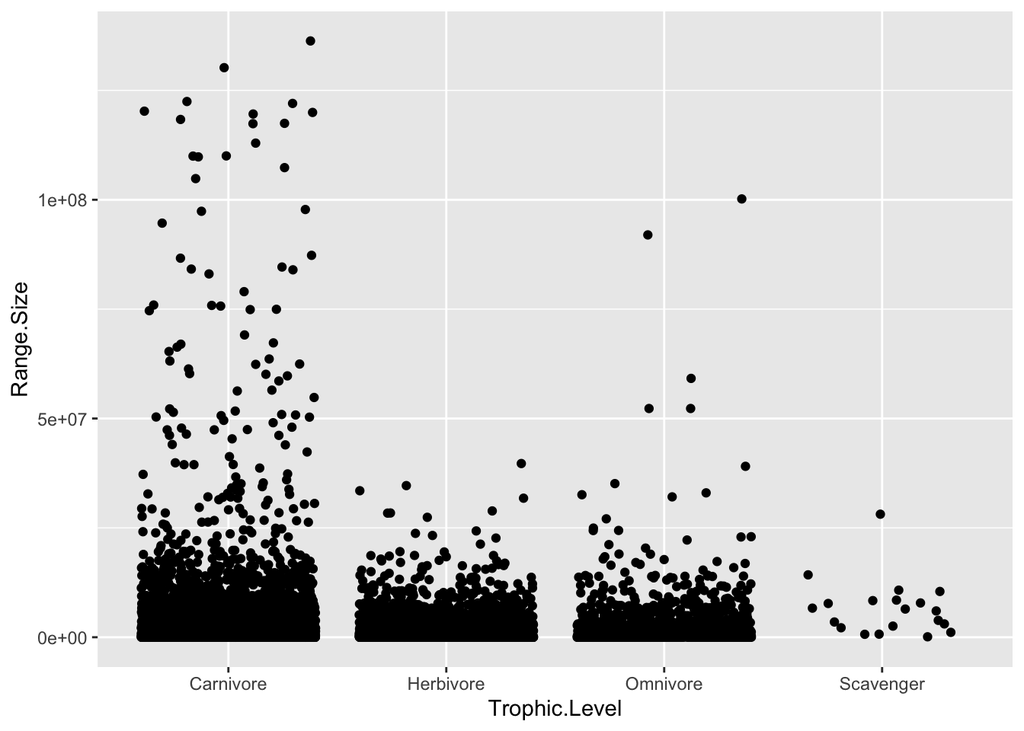

We then decided to try to use a model to predict whether or not a bird was a scavenger by using its range Size value. As we planned to use a logistic regression model, we re-encoded trophic Level as a binary categorical variable, and distinguish scavengers (“yes”) from non-scavengers (“no”).

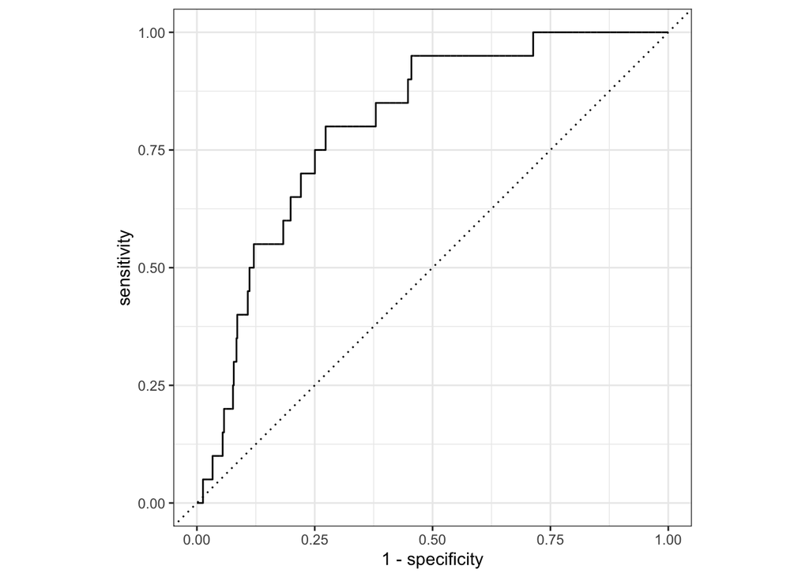

```
## # A tibble: 1 × 3
##   .metric .estimator .estimate
##   <chr>   <chr>          <dbl>
## 1 roc_auc binary         0.803
```

However, a limitation of the model is the very small sample size of scavengers within the data, which was **20**.

```
## # A tibble: 5 × 2
##   Trophic.Level sample_size
##   <fct>               <int>
## 1 Carnivore            5567
## 2 Herbivore            2779
## 3 Omnivore             1623
## 4 Scavenger              20
## 5 <NA>                    4
```

### 4. Predicting Trophic Niche

As we were unsuccessful in predicting trophic level, we moved onto attempting to predict the variable trophic niche: more specifically, whether a bird is an invertivore. We selected hand wing index as a variable and fitted a logistic regression model:

```
## # A tibble: 1,999 × 5
##    .pred_0 .pred_1 Trophic.Niche `Hand-Wing.Index` Invertivore
##      <dbl>   <dbl> <chr>                     <dbl> <chr>
##  1   0.637   0.363 Vertivore                  33.9 0
##  2   0.577   0.423 Vertivore                  29   0
##  3   0.603   0.397 Vertivore                  31.1 0
##  4   0.551   0.449 Vertivore                  27   0
##  5   0.589   0.411 Vertivore                  30   0
##  6   0.686   0.314 Vertivore                  38.1 0
##  7   0.517   0.483 Vertivore                  24.4 0
##  8   0.704   0.296 Vertivore                  39.7 0
##  9   0.684   0.316 Vertivore                  37.9 0
## 10   0.639   0.361 Vertivore                  34   0
## # ℹ 1,989 more rows
```

We then checked the model performance, which revealed a relatively high AUC of **0.73**, which suggests it’s relatively useful in predicting whether the bird is invertivore or not.

```
## # A tibble: 2 × 3
##   response        `Predicted Invertivore` `Predicted Not Invertivore`
##   <chr>                             <int>                       <int>
## 1 Invertivore                         798                         161
## 2 Not Invertivore                     511                         529
```

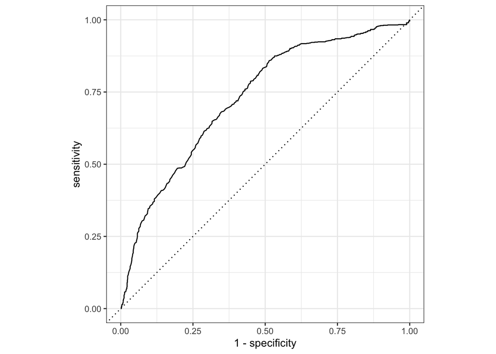

```
## # A tibble: 1 × 3
##   .metric .estimator .estimate
##   <chr>   <chr>          <dbl>
## 1 roc_auc binary         0.730
```

```
## # A tibble: 3 × 6
##   .metric     .estimator  mean     n std_err .config
##   <chr>       <chr>      <dbl> <int>   <dbl> <chr>
## 1 accuracy    binary     0.650     5 0.00431 pre0_mod0_post0
## 2 brier_class binary     0.220     5 0.00106 pre0_mod0_post0
## 3 roc_auc     binary     0.712     5 0.00246 pre0_mod0_post0
```

### 5. Improving our prediction on Trophic Niche

In order to improve the model’s ability to distinguish invertivores from other birds, we added a new variable, mass, to the model. We came to this decision after constructing a `geom_jitter()` plot, which visually suggested some correlation between trophic niche and mass:

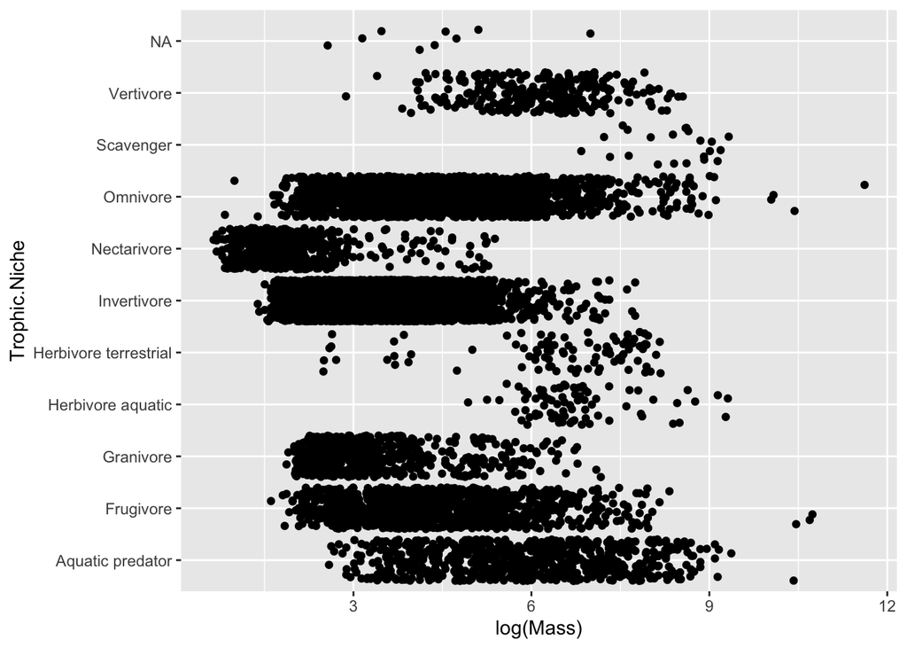

We then fitted a model to our chosen variables:

```
## # A tibble: 1,999 × 6
##    .pred_0  .pred_1 Trophic.Niche `Hand-Wing.Index`  Mass Invertivore
##      <dbl>    <dbl> <chr>                     <dbl> <dbl> <chr>
##  1   0.762 2.38e- 1 Vertivore                  33.9  249. 0
##  2   0.587 4.13e- 1 Vertivore                  29    125  0
##  3   0.832 1.68e- 1 Vertivore                  31.1  359. 0
##  4   0.992 7.66e- 3 Vertivore                  27   1050  0
##  5   0.801 1.99e- 1 Vertivore                  30    326. 0
##  6   0.746 2.54e- 1 Vertivore                  38.1  198  0
##  7   0.687 3.13e- 1 Vertivore                  24.4  249. 0
##  8   1.000 3.60e- 7 Vertivore                  39.7 2958  0
##  9   1.000 2.09e- 5 Vertivore                  37.9 2154. 0
## 10   1.000 9.74e-10 Vertivore                  34   4195  0
## # ℹ 1,989 more rows
```

We then tested our model’s performance:

```
## # A tibble: 2 × 3
##   response        `Predicted Invertivore` `Predicted Not Invertivore`
##   <chr>                             <int>                       <int>
## 1 Invertivore                         845                         114
## 2 Not Invertivore                     471                         569
```

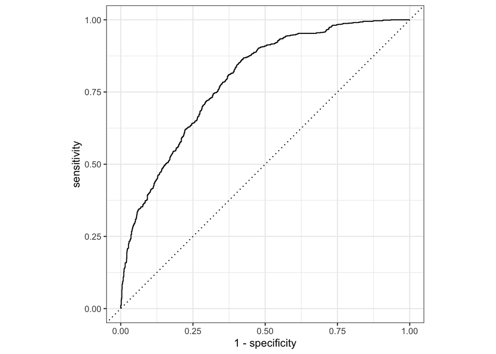

```
## # A tibble: 1 × 3
##   .metric .estimator .estimate
##   <chr>   <chr>          <dbl>
## 1 roc_auc binary         0.792
```

```
## → A | warning: glm.fit: fitted probabilities numerically 0 or 1 occurred
```

[output not shown]

[output not shown]

```
## [1] 0.8739566
```

```
## [1] 0.5495772
```

The AUC increased from **0.73** to **0.79**, which suggests an improvement on the model’s ability to predict whether a bird is an invertivore.